# R Notebook

> We analyzed each derived trait axis individually using met- rics we term either multipattern, single-niche axis, because they test for both assembly patterns (clustering and ov- erdispersion), or single-pattern, single-niche axis, because they test for only one assembly pattern. We focused on three multipattern, single-niche–axis metrics: (1) FD ap- plied to a single trait axis, (2) variance (the variance in species values within a community along a single trait axis), and (3) range (the range in species trait values within a community, i.e., the single-niche-axis equivalent of CHV). Both variance and range have previously been used predominantly as a measure of trait clustering (e.g., Stubbs and Wilson 2004; Kraft and Ackerly 2010). We also focused on one single-pattern, single-niche–axis metric, SDNDr, the standard deviation of the distances between neigh- boring species along a single trait axis, divided by the trait range of the community. The metric SDNDr is used to detect only the regular spacing in species trait values pre- dicted by competitive exclusion (Kraft and Ackerly 2010) — Triso et al. (2014)

> We sampled multiple specimens for all species recorded in our study, taking seven measurements from each specimen: bill length, width, and depth, wing length, length of primary projection, tarsus length and tail length. We then used these measurements to generate four categories of functionaltrait: overall body size, trophic traits, locomotory traits,and dispersal traits. Specifically, following Trisos et al. (2014), we used a two-step principal component analysis (PCA) on averaged morphological traits related to different ecological characteristics. Initially, PCAs were separately undertaken on locomotory (tail, wing, and tarsus length) and trophic (beak length, width, and epth) traits. The second components of the locomotory (short tarsus : long tail/wing) and trophic (short beak : wide/deep beak) PCAs were used as the respective trait axes. The first components of each of these PCAs were strongly related to size, so we combined them in a second PCA to form an axis of overall body size. The dispersal trait was the final axis and consisted of the log- transformed hand-wing index (Claramunt et al. 2012; also see Appendix B) We adopted this two-step approach because it accounts for correlation between traits, particularly the correlation of all traits with body size, and thus outperforms standard ordination technique — Bergman et al. (2015)

```r
library(dplyr)
library(tidyverse)
library(factoextra)
library(densityClust)
library(stats)
library(sf)
library(ggpubr)
library(grid)
library(vegan)
library(phytools)
library(picante)
rm(list = ls())
```

```r
col_loc = read_csv('./bigquery_export__columbidae_birdlife_urban_locations.csv')
head(col_loc)
```

| city_id | city_name | species_name | season_code | present_in_city |
| --- | --- | --- | --- | --- |
| 1 | Honolulu | Spilopelia chinensis | 1 | FALSE |
| 514 | Cali | Columbina passerina | 1 | FALSE |
| 514 | Cali | Columbina talpacoti | 1 | TRUE |
| 514 | Cali | Geotrygon montana | 1 | FALSE |
| 514 | Cali | Paraclaravis mondetoura | 1 | FALSE |
| 514 | Cali | Leptotila plumbeiceps | 1 | FALSE |

```r
col_ut = read_csv('./bigquery_export__columbidae_birdlife_urban_tolerance.csv')
head(col_ut)
```

| species_name | region_count | city_count | urban_tolerance |
| --- | --- | --- | --- |
| Macropygia tenuirostris | 1 | 1 | 1 |
| Ducula carola | 1 | 1 | 1 |
| Ducula poliocephala | 1 | 0 | 0 |
| Gallicolumba crinigera | 1 | 0 | 0 |
| Ramphiculus occipitalis | 1 | 0 | 0 |
| Treron axillaris | 1 | 0 | 0 |

```r
avonet_birdlife = read_csv('./avonet_birdlife.csv')
head(avonet_birdlife)
```

| Sequence | Species1 | Family1 | Order1 | Avibase.ID1 | Total.individuals | Female | Male | Unknown | Complete.measures | Beak.Length_Culmen | Beak.Length_Nares | Beak.Width | Beak.Depth | Tarsus.Length | Wing.Length | Kipps.Distance | Secondary1 | Hand-Wing.Index | Tail.Length | Mass | Mass.Source | Mass.Refs.Other | Inference | Traits.inferred | Reference.species | Habitat | Habitat.Density | Migration | Trophic.Level | … |
| --- | --- | --- | --- | --- | --- | --- | --- | --- | --- | --- | --- | --- | --- | --- | --- | --- | --- | --- | --- | --- | --- | --- | --- | --- | --- | --- | --- | --- | --- | --- |
| 894 | Alectroenas madagascariensis | Columbidae | Columbiformes | AVIBASE-F87511B3 | 4 | 2 | 2 | 0 | 4 | 17.5 | 9.2 | 4.1 | 4.2 | 22.3 | 171.0 | 57.5 | 113.5 | 33.6 | 81.5 | 173.0 | Dunning | NA | NO | NA | NA | Forest | 2 | 1 | Herbivore | … |
| 896 | Alectroenas pulcherrimus | Columbidae | Columbiformes | AVIBASE-576B77A3 | 5 | 2 | 2 | 1 | 4 | 20.6 | 9.4 | 4.5 | 4.8 | 25.5 | 160.4 | 40.8 | 121.0 | 25.2 | 81.2 | 165.0 | Dunning | NA | NO | NA | NA | Forest | 2 | 1 | Herbivore | … |
| 895 | Alectroenas sganzini | Columbidae | Columbiformes | AVIBASE-E396A643 | 5 | 2 | 3 | 0 | 4 | 19.3 | 8.8 | 4.4 | 4.3 | 25.3 | 164.2 | 50.2 | 113.5 | 30.7 | 93.0 | 158.0 | Dunning | NA | NO | NA | NA | Forest | 2 | 1 | Herbivore | … |
| 752 | Alopecoenas beccarii | Columbidae | Columbiformes | AVIBASE-51D9E97E | 4 | 2 | 2 | 0 | 4 | 15.6 | 9.1 | 2.1 | 2.8 | 27.5 | 103.0 | 30.5 | 72.5 | 29.6 | 55.5 | 78.7 | Dunning | NA | NO | NA | NA | Forest | 1 | 1 | Herbivore | … |
| 754 | Alopecoenas canifrons | Columbidae | Columbiformes | AVIBASE-40866A35 | 1 | 0 | 0 | 1 | 1 | 20.6 | 9.7 | 2.8 | 3.7 | 30.9 | 113.0 | 30.0 | 83.0 | 26.5 | 63.0 | 135.0 | Inferred | NA | YES | Body Mass | Alopecoenas jobiensis | Forest | 1 | 1 | Herbivore | … |
| 750 | Alopecoenas erythropterus | Columbidae | Columbiformes | AVIBASE-DD2985FA | 4 | 1 | 3 | 0 | 4 | 20.7 | 11.1 | 3.6 | 4.3 | 31.6 | 140.5 | 43.2 | 97.2 | 30.8 | 73.5 | 113.2 | Dunning | NA | NO | NA | NA | Woodland | 1 | 1 | Herbivore | … |

### Check we have traits for all species in our dataset

```r
distinct(col_loc[!col_loc$species_name %in% avonet_birdlife$Species1,])
```

| city_id | city_name | species_name | season_code | present_in_city |
| --- | --- | --- | --- | --- |

```r
distinct(col_ut[!col_ut$species_name %in% avonet_birdlife$Species1,])
```

| species_name | region_count | city_count | urban_tolerance |
| --- | --- | --- | --- |

> locomotory (tail, wing, and tarsus length) trophic (beak length, width, and depth) traits — Bregman et al. (2015): https://esajournals.onlinelibrary.wiley.com/doi/full/10.1890/14-1731.1 — Trisos et al. (2014)

```r
col_traits = avonet_birdlife[avonet_birdlife$Species1 %in% col_loc$species_name,c('Species1', 'Beak.Length_Culmen', 'Beak.Width', 'Beak.Depth', 'Tail.Length', 'Hand-Wing.Index', 'Tarsus.Length', 'Habitat', 'Habitat.Density', 'Trophic.Niche', 'Primary.Lifestyle', 'Range.Size', 'Mass')]
names(col_traits) <- c('species_name', 'beak_length', 'beak_width', 'beak_depth', 'tail_length', 'wing_index', 'tarsus_length', 'habitat', 'habitat_density', 'trophic_niche', 'primary_lifestyle', 'range_size', 'mass')
col_traits
```

| species_name | beak_length | beak_width | beak_depth | tail_length | wing_index | tarsus_length | habitat | habitat_density | trophic_niche | primary_lifestyle | range_size | mass |
| --- | --- | --- | --- | --- | --- | --- | --- | --- | --- | --- | --- | --- |
| Alectroenas madagascariensis | 17.5 | 4.1 | 4.2 | 81.5 | 33.6 | 22.3 | Forest | 2 | Frugivore | Insessorial | 311714.72 | 173.0 |
| Alopecoenas hoedtii | 18.8 | 3.9 | 4.8 | 102.3 | 28.7 | 27.0 | Forest | 1 | Frugivore | Terrestrial | 27951.31 | 135.0 |
| Aplopelia larvata | 21.7 | 3.3 | 3.7 | 92.9 | 29.3 | 26.0 | Forest | 2 | Granivore | Terrestrial | 2621498.99 | 155.0 |
| Caloenas nicobarica | 30.7 | 5.4 | 7.7 | 98.8 | 32.8 | 43.7 | Forest | 1 | Omnivore | Terrestrial | 475640.94 | 537.9 |
| Chalcophaps indica | 20.9 | 3.1 | 4.2 | 83.9 | 28.7 | 25.8 | Forest | 1 | Omnivore | Generalist | 4704607.55 | 136.5 |
| Chalcophaps longirostris | 22.7 | 2.8 | 4.0 | 87.0 | 32.0 | 25.9 | Forest | 1 | Omnivore | Generalist | 639179.72 | 136.5 |
| Claravis pretiosa | 16.6 | 3.2 | 3.6 | 76.1 | 26.7 | 16.3 | Forest | 1 | Granivore | Generalist | 12977823.95 | 68.2 |
| Columba albinucha | 25.4 | 4.2 | 4.6 | 112.0 | 42.0 | 24.0 | Forest | 2 | Frugivore | Insessorial | 79766.00 | 325.0 |
| Columba albitorques | 21.0 | 4.5 | 5.4 | 106.0 | 43.7 | 28.7 | Grassland | 2 | Granivore | Terrestrial | 137598.58 | 277.0 |
| Columba arquatrix | 27.9 | 4.3 | 5.9 | 131.7 | 37.1 | 28.3 | Forest | 2 | Frugivore | Insessorial | 1486805.14 | 400.0 |

[output cut: 162 more lines]

```r
pigeons = left_join(col_ut[,c('species_name', 'urban_tolerance', 'region_count')], col_traits)
pigeons
```

| species_name | urban_tolerance | region_count | beak_length | beak_width | beak_depth | tail_length | wing_index | tarsus_length | habitat | habitat_density | trophic_niche | primary_lifestyle | range_size | mass |
| --- | --- | --- | --- | --- | --- | --- | --- | --- | --- | --- | --- | --- | --- | --- |
| Macropygia tenuirostris | 1.00 | 1 | 20.5 | 3.6 | 4.8 | 187.2 | 33.2 | 21.6 | Forest | 1 | Frugivore | Insessorial | 282345.03 | 177.0 |
| Ducula carola | 1.00 | 1 | 25.1 | 6.0 | 5.6 | 120.2 | 36.5 | 25.9 | Forest | 1 | Frugivore | Insessorial | 222701.31 | 289.0 |
| Ducula poliocephala | 0.00 | 1 | 29.3 | 6.4 | 6.0 | 149.8 | 29.8 | 30.0 | Forest | 2 | Frugivore | Insessorial | 266333.85 | 555.0 |
| Gallicolumba crinigera | 0.00 | 1 | 20.3 | 3.1 | 4.5 | 97.2 | 28.6 | 36.1 | Forest | 1 | Omnivore | Terrestrial | 94066.40 | 192.2 |
| Ramphiculus occipitalis | 0.00 | 1 | 19.1 | 4.3 | 5.4 | 102.8 | 26.7 | 26.1 | Forest | 2 | Frugivore | Insessorial | 267780.83 | 238.0 |
| Treron axillaris | 0.00 | 1 | 22.2 | 5.3 | 6.6 | 79.0 | 36.0 | 25.1 | Forest | 2 | Frugivore | Insessorial | 275189.62 | 234.0 |
| Phapitreron amethystinus | 0.00 | 1 | 25.9 | 5.2 | 6.3 | 103.7 | 33.5 | 20.5 | Forest | 1 | Omnivore | Insessorial | 227781.90 | 145.0 |
| Phapitreron brevirostris | 0.00 | 1 | 18.4 | 3.5 | 4.6 | 77.0 | 33.6 | 16.9 | Forest | 1 | Frugivore | Insessorial | 122038.36 | 108.0 |
| Phapitreron brunneiceps | 0.00 | 1 | 25.3 | 4.6 | 6.4 | 96.2 | 36.3 | 20.5 | Forest | 1 | Omnivore | Insessorial | 95407.83 | 146.0 |
| Streptopelia dusumieri | 0.00 | 1 | 21.2 | 3.6 | 4.4 | 112.7 | 32.2 | 24.1 | Woodland | 3 | Granivore | Terrestrial | 277310.82 | 153.0 |

[output cut: 162 more lines]

```r
pigeons5 = pigeons[pigeons$region_count >= 5,]
```

```r
shapiro.test(pigeons$urban_tolerance) #p <= 0.05   -> Significantly different from normal
```

```
    Shapiro-Wilk normality test

data:  pigeons$urban_tolerance
W = 0.63429, p-value < 2.2e-16
```

# Compare Trophic niches

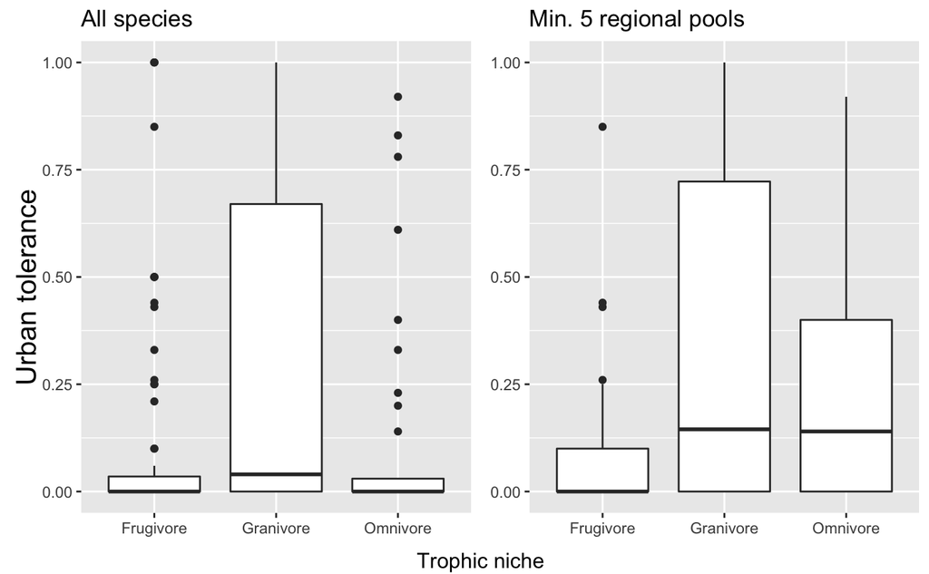

```r
figure1 = ggarrange(ncol = 2, nrow = 1,
  ggplot(pigeons, aes(x = trophic_niche, y = urban_tolerance)) +
    geom_boxplot() + labs(title = "All species") + rremove("ylab") + rremove("xlab"),
  ggplot(pigeons5, aes(x = trophic_niche, y = urban_tolerance)) +
    geom_boxplot() + labs(title = "Min. 5 regional pools") + rremove("ylab") + rremove("xlab")
)

annotate_figure(figure1, left = textGrob("Urban tolerance", rot = 90, vjust = 1, gp = gpar(cex = 1.3)),
                    bottom = textGrob("Trophic niche"))
```

```r
kruskal.test(pigeons$urban_tolerance~pigeons$trophic_niche)
```

```
    Kruskal-Wallis rank sum test

data:  pigeons$urban_tolerance by pigeons$trophic_niche
Kruskal-Wallis chi-squared = 14.818, df = 2, p-value = 0.0006058
```

```r
pairwise.wilcox.test(pigeons$urban_tolerance, pigeons$trophic_niche)
```

```
    Pairwise comparisons using Wilcoxon rank sum test with continuity correction

data:  pigeons$urban_tolerance and pigeons$trophic_niche

          Frugivore Granivore
Granivore 0.0017    -
Omnivore  0.9967    0.0107

P value adjustment method: holm
```

```
-
- Urban tolerance was significantly different between different trophic niches (Chi-squared=14.8, df=2, p<0.001), with urban tolerance significantly
- lower in Frugivores compared to Granivores.
-
```

```r
kruskal.test(pigeons5$urban_tolerance~pigeons5$trophic_niche)
```

```
    Kruskal-Wallis rank sum test

data:  pigeons5$urban_tolerance by pigeons5$trophic_niche
Kruskal-Wallis chi-squared = 7.7382, df = 2, p-value = 0.02088
```

```r
pairwise.wilcox.test(pigeons5$urban_tolerance, pigeons5$trophic_niche)
```

```
    Pairwise comparisons using Wilcoxon rank sum test with continuity correction

data:  pigeons5$urban_tolerance and pigeons5$trophic_niche

          Frugivore Granivore
Granivore 0.019     -
Omnivore  0.164     0.570

P value adjustment method: holm
```

## Get mean + sd by trophic niche

```r
pigeons %>% group_by(trophic_niche) %>% summarise(mean = mean(urban_tolerance), sd = sd(urban_tolerance), min = min(urban_tolerance), max = max(urban_tolerance))
```

| trophic_niche | mean | sd | min | max |
| --- | --- | --- | --- | --- |
| Frugivore | 0.1120000 | 0.2509148 | 0 | 1.00 |
| Granivore | 0.2943077 | 0.3710415 | 0 | 1.00 |
| Omnivore | 0.1208108 | 0.2559338 | 0 | 0.92 |

# Compare Habitat

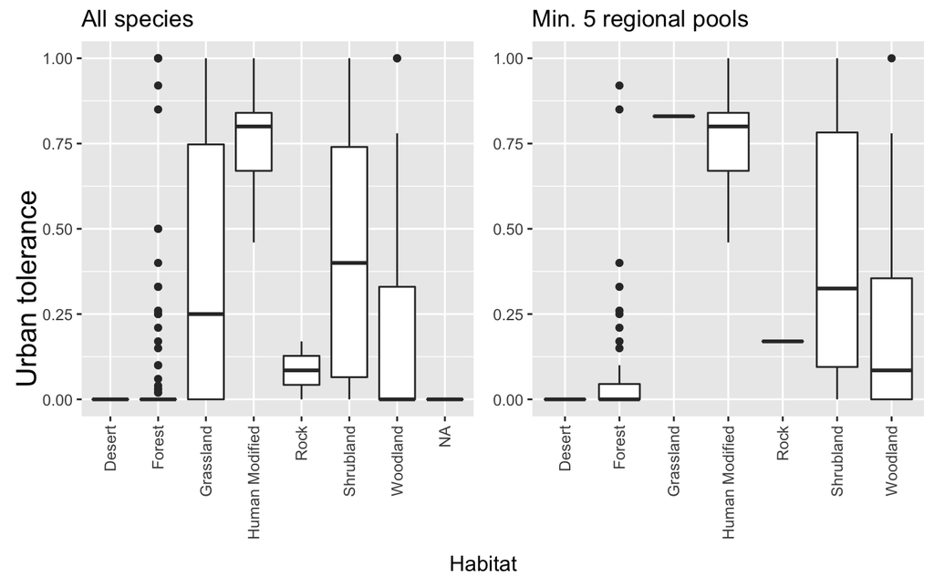

```r
figure2 = ggarrange(ncol = 2, nrow = 1,
  ggplot(pigeons, aes(x = habitat, y = urban_tolerance)) +
    geom_boxplot() + labs(title = "All species") + rremove("ylab") + rremove("xlab") + theme(axis.text.x = element_text(angle = 90, vjust = 0.5, hjust=1)),
  ggplot(pigeons5, aes(x = habitat, y = urban_tolerance)) +
    geom_boxplot() + labs(title = "Min. 5 regional pools") + rremove("ylab") + rremove("xlab") + theme(axis.text.x = element_text(angle = 90, vjust = 0.5, hjust=1))
)

annotate_figure(figure2, left = textGrob("Urban tolerance", rot = 90, vjust = 1, gp = gpar(cex = 1.3)),
                    bottom = textGrob("Habitat"))
```

```r
kruskal.test(pigeons$urban_tolerance~pigeons$habitat)
```

```
    Kruskal-Wallis rank sum test

data:  pigeons$urban_tolerance by pigeons$habitat
Kruskal-Wallis chi-squared = 54.206, df = 6, p-value = 6.704e-10
```

```r
pairwise.wilcox.test(pigeons$urban_tolerance, pigeons$habitat)
```

```
    Pairwise comparisons using Wilcoxon rank sum test with continuity correction

data:  pigeons$urban_tolerance and pigeons$habitat

               Desert Forest  Grassland Human Modified Rock   Shrubland
Forest         1.0000 -       -         -              -      -
Grassland      1.0000 0.7359  -         -              -      -
Human Modified 1.0000 2.1e-07 1.0000    -              -      -
Rock           1.0000 1.0000  1.0000    0.7064         -      -
Shrubland      1.0000 3.7e-07 1.0000    0.7301         1.0000 -
Woodland       1.0000 0.0793  1.0000    0.0077         1.0000 0.4749

P value adjustment method: holm
```

[output not shown]

```r
kruskal.test(pigeons5$urban_tolerance~pigeons5$habitat)
```

```
    Kruskal-Wallis rank sum test

data:  pigeons5$urban_tolerance by pigeons5$habitat
Kruskal-Wallis chi-squared = 37.529, df = 6, p-value = 1.388e-06
```

```r
pairwise.wilcox.test(pigeons5$urban_tolerance, pigeons5$habitat)
```

```
    Pairwise comparisons using Wilcoxon rank sum test with continuity correction

data:  pigeons5$urban_tolerance and pigeons5$habitat

               Desert  Forest  Grassland Human Modified Rock    Shrubland
Forest         1.00000 -       -         -              -       -
Grassland      1.00000 1.00000 -         -              -       -
Human Modified 1.00000 3.7e-05 1.00000   -              -       -
Rock           1.00000 1.00000 1.00000   1.00000        -       -
Shrubland      1.00000 0.00038 1.00000   1.00000        1.00000 -
Woodland       1.00000 0.95265 1.00000   0.01383        1.00000 1.00000

P value adjustment method: holm
```

## Get mean + sd by habitat

```r
pigeons %>% group_by(habitat) %>% summarise(mean = mean(urban_tolerance), sd = sd(urban_tolerance), min = min(urban_tolerance), max = max(urban_tolerance))
```

| habitat | mean | sd | min | max |
| --- | --- | --- | --- | --- |
| Desert | 0.00000000 | NA | 0.00 | 0.00 |
| Forest | 0.07816514 | 0.2172350 | 0.00 | 1.00 |
| Grassland | 0.38833333 | 0.4547710 | 0.00 | 1.00 |
| Human Modified | 0.74444444 | 0.1588325 | 0.46 | 1.00 |
| Rock | 0.08500000 | 0.1202082 | 0.00 | 0.17 |
| Shrubland | 0.42789474 | 0.3645024 | 0.00 | 1.00 |
| Woodland | 0.22360000 | 0.3241126 | 0.00 | 1.00 |
| NA | 0.00000000 | NA | 0.00 | 0.00 |

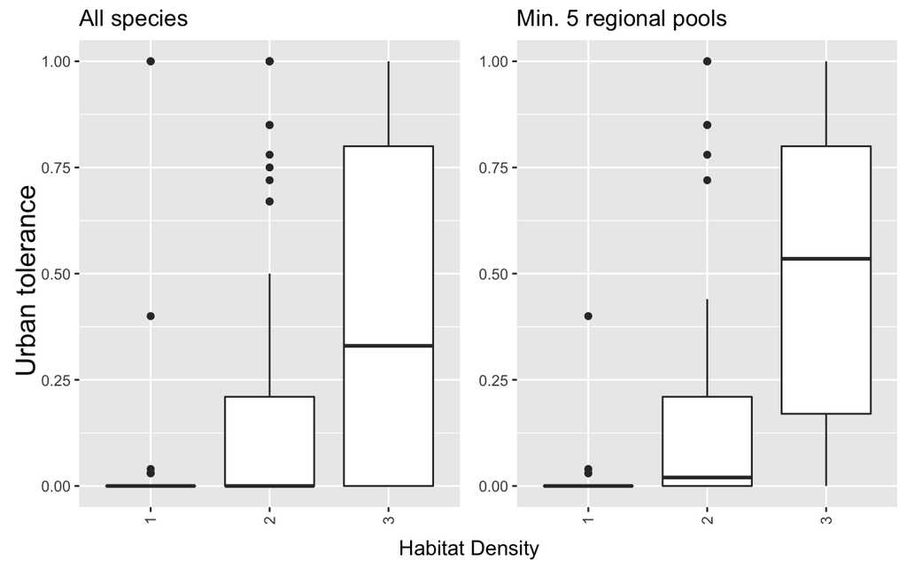

```r
figure3 = ggarrange(ncol = 2, nrow = 1,
  ggplot(pigeons, aes(x = as.factor(habitat_density), y = urban_tolerance)) +
    geom_boxplot() + labs(title = "All species") + rremove("ylab") + rremove("xlab") + theme(axis.text.x = element_text(angle = 90, vjust = 0.5, hjust=1)),
  ggplot(pigeons5, aes(x = as.factor(habitat_density), y = urban_tolerance)) +
    geom_boxplot() + labs(title = "Min. 5 regional pools") + rremove("ylab") + rremove("xlab") + theme(axis.text.x = element_text(angle = 90, vjust = 0.5, hjust=1))
)

annotate_figure(figure3, left = textGrob("Urban tolerance", rot = 90, vjust = 1, gp = gpar(cex = 1.3)),
                    bottom = textGrob("Habitat Density"))
```

```r
kruskal.test(pigeons$urban_tolerance~pigeons$habitat_density)
```

```
    Kruskal-Wallis rank sum test

data:  pigeons$urban_tolerance by pigeons$habitat_density
Kruskal-Wallis chi-squared = 29.396, df = 2, p-value = 4.138e-07
```

```r
pairwise.wilcox.test(pigeons$urban_tolerance, pigeons$habitat_density)
```

```
    Pairwise comparisons using Wilcoxon rank sum test with continuity correction

data:  pigeons$urban_tolerance and pigeons$habitat_density

  1       2
2 3e-03   -
3 6.5e-07 5e-04

P value adjustment method: holm
```

## Get mean + sd by habitat density

```r
pigeons %>% group_by(habitat_density) %>% summarise(mean = mean(urban_tolerance), sd = sd(urban_tolerance), min = min(urban_tolerance), max = max(urban_tolerance))
```

| habitat_density | mean | sd | min | max |
| --- | --- | --- | --- | --- |
| 1 | 0.05555556 | 0.2145032 | 0 | 1 |
| 2 | 0.16768421 | 0.2980128 | 0 | 1 |
| 3 | 0.40656250 | 0.3631902 | 0 | 1 |

# Compare Lifestyle

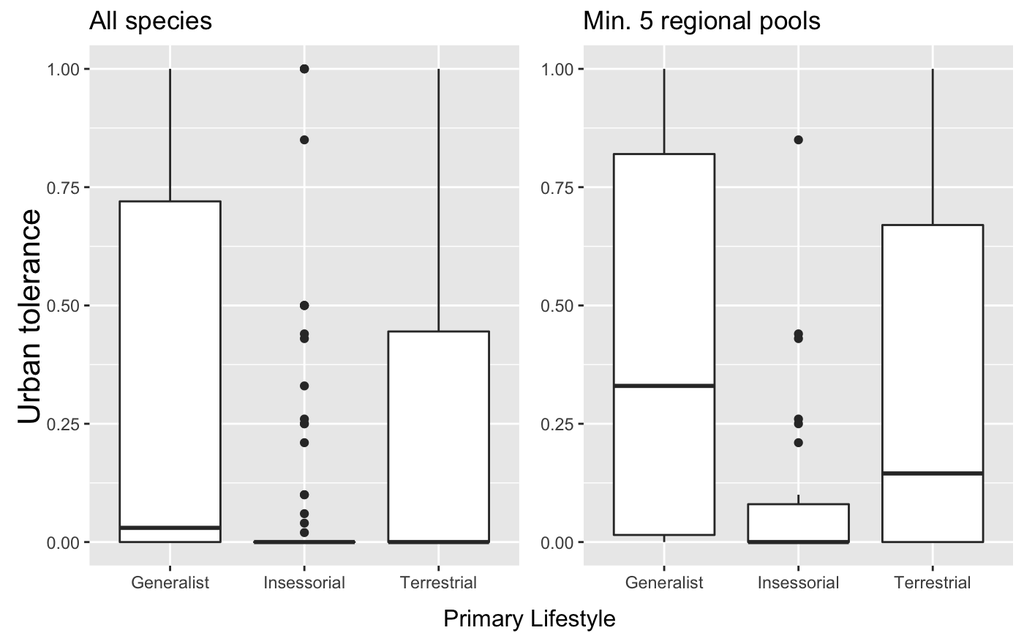

```r
figure4 = ggarrange(ncol = 2, nrow = 1,
  ggplot(pigeons, aes(x = primary_lifestyle, y = urban_tolerance)) +
    geom_boxplot() + labs(title = "All species") + rremove("ylab") + rremove("xlab"),
  ggplot(pigeons5, aes(x = primary_lifestyle, y = urban_tolerance)) +
    geom_boxplot() + labs(title = "Min. 5 regional pools") + rremove("ylab") + rremove("xlab")
)

annotate_figure(figure4, left = textGrob("Urban tolerance", rot = 90, vjust = 1, gp = gpar(cex = 1.3)),
                    bottom = textGrob("Primary Lifestyle"))
```

```r
kruskal.test(pigeons$urban_tolerance~pigeons$primary_lifestyle)
```

```
    Kruskal-Wallis rank sum test

data:  pigeons$urban_tolerance by pigeons$primary_lifestyle
Kruskal-Wallis chi-squared = 11.073, df = 2, p-value = 0.003941
```

```r
pairwise.wilcox.test(pigeons$urban_tolerance, pigeons$primary_lifestyle)
```

```
    Pairwise comparisons using Wilcoxon rank sum test with continuity correction

data:  pigeons$urban_tolerance and pigeons$primary_lifestyle

            Generalist Insessorial
Insessorial 0.0705     -
Terrestrial 0.5246     0.0059

P value adjustment method: holm
```

[output not shown]

```r
kruskal.test(pigeons5$urban_tolerance~pigeons5$primary_lifestyle)
```

```
    Kruskal-Wallis rank sum test

data:  pigeons5$urban_tolerance by pigeons5$primary_lifestyle
Kruskal-Wallis chi-squared = 10.19, df = 2, p-value = 0.006128
```

```r
pairwise.wilcox.test(pigeons5$urban_tolerance, pigeons5$primary_lifestyle)
```

```
    Pairwise comparisons using Wilcoxon rank sum test with continuity correction

data:  pigeons5$urban_tolerance and pigeons5$primary_lifestyle

            Generalist Insessorial
Insessorial 0.0584     -
Terrestrial 0.4880     0.0094

P value adjustment method: holm
```

## Get mean + sd by lifestyle

```r
pigeons %>% group_by(primary_lifestyle) %>% summarise(mean = mean(urban_tolerance), sd = sd(urban_tolerance), min = min(urban_tolerance), max = max(urban_tolerance))
```

| primary_lifestyle | mean | sd | min | max |
| --- | --- | --- | --- | --- |
| Generalist | 0.3333333 | 0.4293309 | 0 | 1 |
| Insessorial | 0.1018182 | 0.2412671 | 0 | 1 |
| Terrestrial | 0.2395349 | 0.3417977 | 0 | 1 |

# Create at locomotion trait

```r
loco_pca = rda(pigeons[,c('tarsus_length', 'wing_index', 'tail_length')])
pigeons$loco_pc1 = loco_pca$Ybar[,1]
pigeons$loco_pc2 = loco_pca$Ybar[,2]
pigeons$loco_pc3 = loco_pca$Ybar[,3]
summary(loco_pca)
```

```
Call:
rda(X = pigeons[, c("tarsus_length", "wing_index", "tail_length")])

Partitioning of variance:
              Inertia Proportion
Total           945.1          1
Unconstrained   945.1          1

Eigenvalues, and their contribution to the variance

Importance of components:
                           PC1     PC2      PC3
Eigenvalue            880.4849 37.8967 26.67139
Proportion Explained    0.9317  0.0401  0.02822
Cumulative Proportion   0.9317  0.9718  1.00000

Scaling 2 for species and site scores
* Species are scaled proportional to eigenvalues
* Sites are unscaled: weighted dispersion equal on all dimensions
* General scaling constant of scores:  20.04994


Species scores

                 PC1      PC2     PC3
tarsus_length  1.018 -3.40550  1.7753
wing_index     1.359  2.12649  2.8472
tail_length   19.278  0.02991 -0.2945


Site scores (weighted sums of species scores)

            PC1       PC2        PC3
sit1    4.01347  0.956145 -2.4338106
sit2    0.58848  0.358754  0.8065564
sit3    2.09889 -1.336301 -1.0017434
sit4   -0.59633 -2.880849  1.0171305
sit5   -0.34217 -1.008538 -1.1698775
sit6   -1.53618  0.385362  1.6254457
sit7   -0.28638  1.073180 -0.3629841
```

[output cut: 150 more lines]

[output not shown]

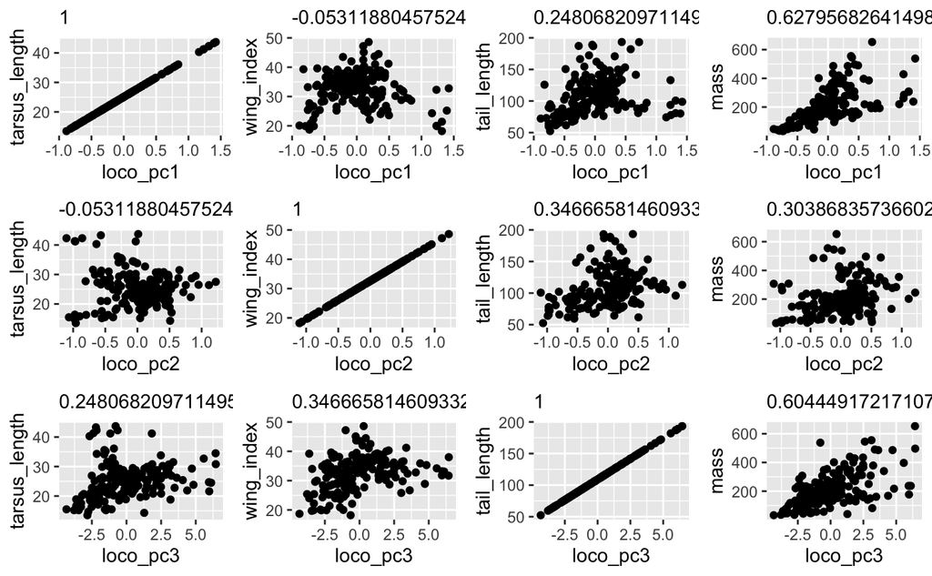

```r
ggarrange(ncol = 4, nrow = 3,
  ggplot(pigeons, aes(x = loco_pc1, y = tarsus_length)) + geom_point() + labs(subtitle = cor(pigeons$loco_pc1,pigeons$tarsus_length)),
  ggplot(pigeons, aes(x = loco_pc1, y = wing_index)) + geom_point() + labs(subtitle = cor(pigeons$loco_pc1,pigeons$wing_index)),
  ggplot(pigeons, aes(x = loco_pc1, y = tail_length)) + geom_point() + labs(subtitle = cor(pigeons$loco_pc1,pigeons$tail_length)),
  ggplot(pigeons, aes(x = loco_pc1, y = mass)) + geom_point() + labs(subtitle = cor(pigeons$loco_pc1,pigeons$mass)),
  ggplot(pigeons, aes(x = loco_pc2, y = tarsus_length)) + geom_point() + labs(subtitle = cor(pigeons$loco_pc2,pigeons$tarsus_length)),
  ggplot(pigeons, aes(x = loco_pc2, y = wing_index)) + geom_point() + labs(subtitle = cor(pigeons$loco_pc2,pigeons$wing_index)),
  ggplot(pigeons, aes(x = loco_pc2, y = tail_length)) + geom_point() + labs(subtitle = cor(pigeons$loco_pc2,pigeons$tail_length)),
  ggplot(pigeons, aes(x = loco_pc2, y = mass)) + geom_point() + labs(subtitle = cor(pigeons$loco_pc2,pigeons$mass)),
  ggplot(pigeons, aes(x = loco_pc3, y = tarsus_length)) + geom_point() + labs(subtitle = cor(pigeons$loco_pc3,pigeons$tarsus_length)),
  ggplot(pigeons, aes(x = loco_pc3, y = wing_index)) + geom_point() + labs(subtitle = cor(pigeons$loco_pc3,pigeons$wing_index)),
  ggplot(pigeons, aes(x = loco_pc3, y = tail_length)) + geom_point() + labs(subtitle = cor(pigeons$loco_pc3,pigeons$tail_length)),
  ggplot(pigeons, aes(x = loco_pc3, y = mass)) + geom_point() + labs(subtitle = cor(pigeons$loco_pc3,pigeons$mass))
)
```

# Create at trophic trait

```r
trophic_pca = rda(pigeons[,c('beak_length', 'beak_width', 'beak_depth')])
pigeons$trophic_pc1 = trophic_pca$Ybar[,1]
pigeons$trophic_pc2 = trophic_pca$Ybar[,2]
pigeons$trophic_pc3 = trophic_pca$Ybar[,3]
summary(trophic_pca)
```

```
Call:
rda(X = pigeons[, c("beak_length", "beak_width", "beak_depth")])

Partitioning of variance:
              Inertia Proportion
Total           19.88          1
Unconstrained   19.88          1

Eigenvalues, and their contribution to the variance

Importance of components:
                          PC1     PC2      PC3
Eigenvalue            18.1355 1.55914 0.181116
Proportion Explained   0.9124 0.07844 0.009112
Cumulative Proportion  0.9124 0.99089 1.000000

Scaling 2 for species and site scores
* Species are scaled proportional to eigenvalues
* Sites are unscaled: weighted dispersion equal on all dimensions
* General scaling constant of scores:  7.635366


Species scores

              PC1     PC2       PC3
beak_length 6.902 -0.6912 -0.007131
beak_width  1.603  1.4221 -0.520239
beak_depth  1.730  1.4398  0.510434


Site scores (weighted sums of species scores)

             PC1        PC2       PC3
sit1   -0.133541 -0.0885871  0.496351
sit2    0.561613  0.2143357 -1.147023
sit3    1.131595 -0.1701534 -1.210784
sit4   -0.184314 -0.3082918  0.700431
sit5   -0.274574  0.5295926  0.406141
sit6    0.196790  0.7498090  0.538237
sit7    0.664068  0.0650263  0.298250
```

[output cut: 150 more lines]

[output not shown]

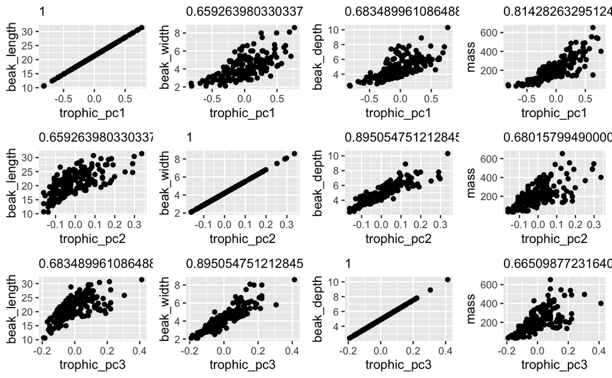

```r
ggarrange(ncol = 4, nrow = 3,
  ggplot(pigeons, aes(x = trophic_pc1, y = beak_length)) + geom_point() + labs(subtitle = cor(pigeons$trophic_pc1,pigeons$beak_length)),
  ggplot(pigeons, aes(x = trophic_pc1, y = beak_width)) + geom_point() + labs(subtitle = cor(pigeons$trophic_pc1,pigeons$beak_width)),
  ggplot(pigeons, aes(x = trophic_pc1, y = beak_depth)) + geom_point() + labs(subtitle = cor(pigeons$trophic_pc1,pigeons$beak_depth)),
  ggplot(pigeons, aes(x = trophic_pc1, y = mass)) + geom_point() + labs(subtitle = cor(pigeons$trophic_pc1,pigeons$mass)),
  ggplot(pigeons, aes(x = trophic_pc2, y = beak_length)) + geom_point() + labs(subtitle = cor(pigeons$trophic_pc2,pigeons$beak_length)),
  ggplot(pigeons, aes(x = trophic_pc2, y = beak_width)) + geom_point() + labs(subtitle = cor(pigeons$trophic_pc2,pigeons$beak_width)),
  ggplot(pigeons, aes(x = trophic_pc2, y = beak_depth)) + geom_point() + labs(subtitle = cor(pigeons$trophic_pc2,pigeons$beak_depth)),
  ggplot(pigeons, aes(x = trophic_pc2, y = mass)) + geom_point() + labs(subtitle = cor(pigeons$trophic_pc2,pigeons$mass)),
  ggplot(pigeons, aes(x = trophic_pc3, y = beak_length)) + geom_point() + labs(subtitle = cor(pigeons$trophic_pc3,pigeons$beak_length)),
  ggplot(pigeons, aes(x = trophic_pc3, y = beak_width)) + geom_point() + labs(subtitle = cor(pigeons$trophic_pc3,pigeons$beak_width)),
  ggplot(pigeons, aes(x = trophic_pc3, y = beak_depth)) + geom_point() + labs(subtitle = cor(pigeons$trophic_pc3,pigeons$beak_depth)),
  ggplot(pigeons, aes(x = trophic_pc3, y = mass)) + geom_point() + labs(subtitle = cor(pigeons$trophic_pc3,pigeons$mass))
)
```

## Look at traits distribution using picante

```r
mapping = read_csv('./bigquery_export__columbidae_taxonomic_mapping.csv')
```

```r
pigeons_jetz = left_join(pigeons, mapping)
pigeons_jetz = pigeons_jetz %>% group_by(jetz_scientific_name) %>% summarise(locomotion = mean(loco_pc1), trophic = mean(trophic_pc1))
picante_traits = pigeons_jetz[,c('jetz_scientific_name', 'locomotion', 'trophic')]
picante_traits = tibble::column_to_rownames(picante_traits, var='jetz_scientific_name')
picante_traits = as.matrix(picante_traits)
```

```r
tree <- read.tree("./phylogeny__stage2_hackett_mcc_no_neg.tre")
```

```r
tree_pruned_to_columbidae <- ladderize(drop.tip(tree, setdiff(tree$tip.label, rownames(picante_traits))))
```

```r
phydist <- cophenetic(tree_pruned_to_columbidae)
```

```r
par(mfrow=c(1,2))
plot(tree_pruned_to_columbidae, show.tip.label=FALSE, main='locomotion')
tiplabels(pch=22, col=picante_traits[,1], bg=picante_traits[,1], cex=1.5)
```

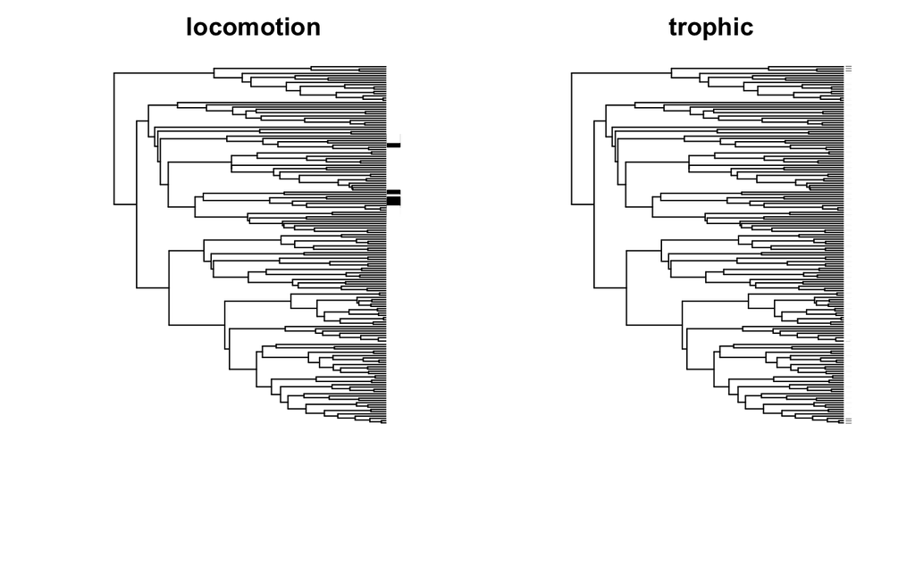

```r
plot(tree_pruned_to_columbidae, show.tip.label=FALSE, main='trophic')
tiplabels(pch=22, col=picante_traits[,2], bg=picante_traits[,0], cex=1.5)
```

## How do these new traits vary with habitat, trophic niche, and lifestyle?

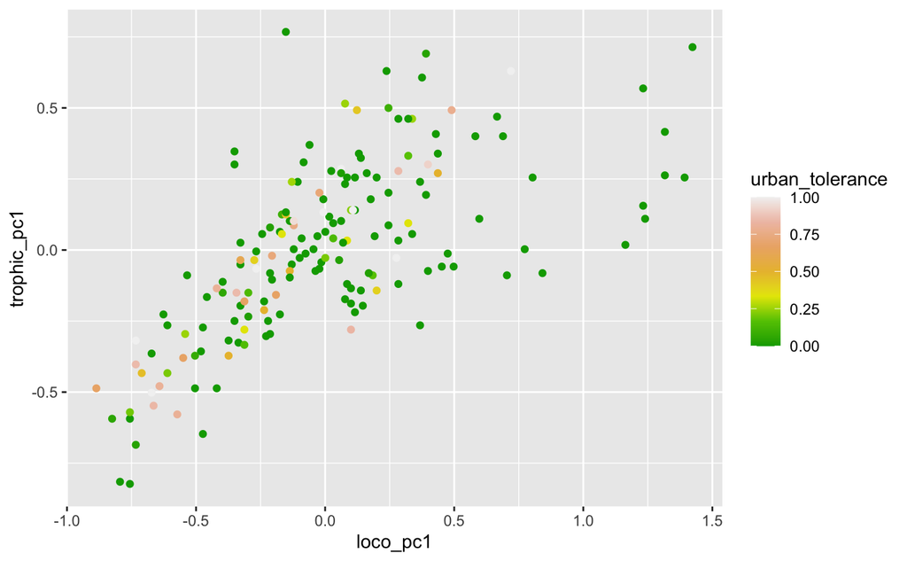

```r
ggplot(pigeons, aes(x = loco_pc1, y = trophic_pc1, color = urban_tolerance)) + geom_point() + scale_color_gradientn(colours = terrain.colors(7))
```

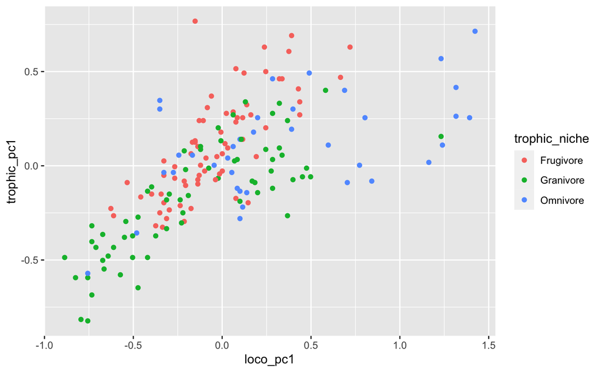

```r
ggplot(pigeons, aes(x = loco_pc1, y = trophic_pc1, color = trophic_niche)) + geom_point()
```

```r
summary(glm(data = pigeons, formula = as.factor(trophic_niche) ~ loco_pc1 * trophic_pc1, family = binomial))
```

```
Call:
glm(formula = as.factor(trophic_niche) ~ loco_pc1 * trophic_pc1,
    family = binomial, data = pigeons)

Deviance Residuals:
    Min       1Q   Median       3Q      Max
-1.8990  -0.9456   0.4101   0.9139   2.4240

Coefficients:
                     Estimate Std. Error z value Pr(>|z|)
(Intercept)            0.2704     0.2139   1.264   0.2063
loco_pc1               2.9917     0.7618   3.927 8.59e-05 ***
trophic_pc1           -5.0802     1.0243  -4.960 7.06e-07 ***
loco_pc1:trophic_pc1   2.8021     1.5655   1.790   0.0735 .
---
Signif. codes:  0 ‘***’ 0.001 ‘**’ 0.01 ‘*’ 0.05 ‘.’ 0.1 ‘ ’ 1

(Dispersion parameter for binomial family taken to be 1)

    Null deviance: 232.45  on 171  degrees of freedom
Residual deviance: 186.99  on 168  degrees of freedom
AIC: 194.99

Number of Fisher Scoring iterations: 5
```

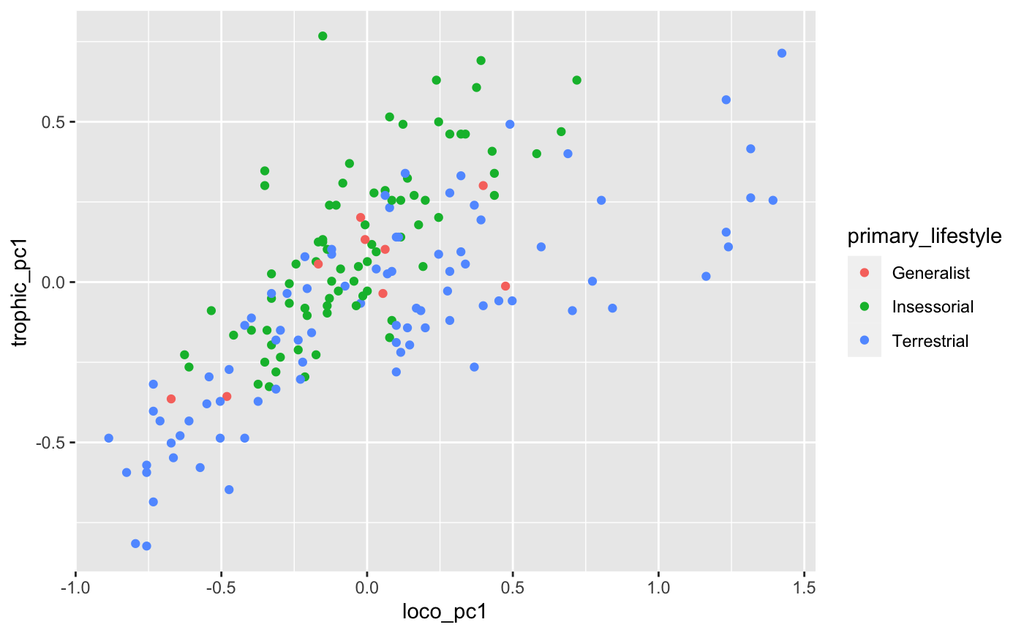

```r
ggplot(pigeons, aes(x = loco_pc1, y = trophic_pc1, color = primary_lifestyle)) + geom_point()
```

```r
summary(glm(data = pigeons[pigeons$primary_lifestyle != 'Generalist',], formula = as.factor(primary_lifestyle) ~ loco_pc1 * trophic_pc1, family = binomial))
```

```
Call:
glm(formula = as.factor(primary_lifestyle) ~ loco_pc1 * trophic_pc1,
    family = binomial, data = pigeons[pigeons$primary_lifestyle !=
        "Generalist", ])

Deviance Residuals:
    Min       1Q   Median       3Q      Max
-1.8097  -0.8721   0.1276   0.7147   2.0337

Coefficients:
                     Estimate Std. Error z value Pr(>|z|)
(Intercept)           -0.1377     0.2375  -0.580    0.562
loco_pc1               4.2139     0.9232   4.564 5.01e-06 ***
trophic_pc1           -7.4306     1.2968  -5.730 1.01e-08 ***
loco_pc1:trophic_pc1   3.9434     1.8175   2.170    0.030 *
---
Signif. codes:  0 ‘***’ 0.001 ‘**’ 0.01 ‘*’ 0.05 ‘.’ 0.1 ‘ ’ 1

(Dispersion parameter for binomial family taken to be 1)

    Null deviance: 225.47  on 162  degrees of freedom
Residual deviance: 154.21  on 159  degrees of freedom
AIC: 162.21

Number of Fisher Scoring iterations: 5
```

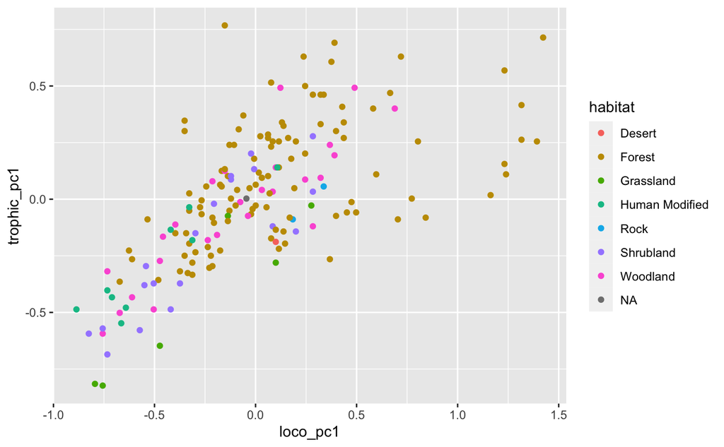

```r
ggplot(pigeons, aes(x = loco_pc1, y = trophic_pc1, color = habitat)) + geom_point()
```

```r
summary(glm(data = pigeons, formula = as.factor(habitat) ~ loco_pc1 * trophic_pc1, family = binomial))
```

```
Call:
glm(formula = as.factor(habitat) ~ loco_pc1 * trophic_pc1, family = binomial,
    data = pigeons)

Deviance Residuals:
     Min        1Q    Median        3Q       Max
-2.65963   0.01277   0.05661   0.09726   0.77250

Coefficients:
                     Estimate Std. Error z value Pr(>|z|)
(Intercept)            5.7879     1.9685   2.940  0.00328 **
loco_pc1               0.7281     5.9783   0.122  0.90307
trophic_pc1           10.1035     9.0039   1.122  0.26181
loco_pc1:trophic_pc1  23.8429    26.9738   0.884  0.37673
---
Signif. codes:  0 ‘***’ 0.001 ‘**’ 0.01 ‘*’ 0.05 ‘.’ 0.1 ‘ ’ 1

(Dispersion parameter for binomial family taken to be 1)

    Null deviance: 12.2775  on 170  degrees of freedom
Residual deviance:  9.1131  on 167  degrees of freedom
  (1 observation deleted due to missingness)
AIC: 17.113

Number of Fisher Scoring iterations: 11
```